# Wildfires in the US

Statistical computation and visualization (MATH-517)

Zineb AGNAOU https://github.com/ZinebAg , Fahim BECK https://github.com/FahimBeck , Salima JAOUA https://github.com/salimajaoua , Matias JANVIN https://github.com/matiasjanvin , Seorim PARK https://github.com/seorimpark  
November 19, 2021

## Introduction

Wildfires are uncontrolled fires that burns in the wildland vegetation, often in rural areas. They are not limited to a particular continent or environment, and burned different kinds of ecosystems for hundred of millions of years on Earth (André Gabrielli (2019)). The problem of wildfires is at the stake all over the world, along with the topic of climate change and preservation of nature and ecosystems. There has been several major cases of wildfires recently, increasing in the number and the severity : for instance, the California wildfires in 2020 became one of the largest wildfire season in the California history (Holly Yan, Cheri Mossburg, Artemis Moshtaghian and Paul Vercammen (2020)) with several millions of acres burnt (Topher Gauk-Roger, Stella Chan, Jason Hanna and Steve Almasy (2020)). Also, Turkey went through the worst wildfire season of the country in July and August 2021 (Mert Ozkan and Ezgi Erkoyun (2021)), and the 2019-2020 bushfires in Australia (also known as the Black Summer) killed several billions of animals. A lot of them were endangered species, which some were believed to be driven to extinction from this incidence (Michael Slezak (2020)). Therefore, a lot of countries aim at minimizing the size and the number of occurrences of wildfires, since they can be the cause of many direct and indirect fatalities in humans (Steven Reinberg (2021)), as well as air pollution (Sarah Gibbens (2021)) and the loss of ecosystems and biodiversity (the case of Black Summer).

In order to reduce the number and the severity of wildfires, understanding the main factors at the origin of the catastrophy is necessary. The incidences are very often caused accidentally (burning debris, agricultural activities, campfires, smoking), or intentionally (arson, children). Although the latter case can be prevented, human or non-human accidents can always happen and they are hard to predict (*Wildfire Causes*, n.d.). However, we can suspect that there are certain natural conditions that make those accidents easier to happen and to grow them bigger in size. By identifying them, the states can build a strategy to efficiently suppress wildfire once it happens, and get prepared to fight against for locations that are highly possible to catch fire at a certain period of the year.

In addition, those factors change as the time goes by, and they generate a better or worse conditions for wildfires to happen. For instance, global warming is highly suspected to be one of the main reasons why the wildfires were more recurrent in the recent days Alejandra Borunda (2021). Countries have to undergo climate changes, and those unexpected events can be the seed of the recent disasters.

### Research questions

In this investigation, we set out to answer the following questions:

1. How have the number of fires in the United States of America evolved with time since 1993?
2. How do the land covers vary over time?
3. What are the main factors that cause wildfires ?
4. How are fires distributed across the land covers and meteorological factors?

### Approaches

To answer the above questions we will proceed as follows. A descriptive and visual approach where we will produce interactive plots with information on the different dimensions : geographically temporally and by different factors. Afterward we will look at the distribution of land covers. We will also analyse the variation of land covers in the same location since we noticed it changed in some areas. We will then proceed with the analysis of the number of fires. To do so, we will look at the land covers and meteorological parameters. We noticed that the correlation between parameters was low, we used subsets and we did a quantile regression.

## Sources of information / datasets

To perform this analysis, we use a dataset for the United States from 1993 to 2015. It contains 563,983 rows with 37 columns. The columns are the following:

- CNT – number of wildfires
- BA – aggregated burnt area of wildfires in acres
- lon – longitude coordinate of grid cell center
- lat – latitude coordinate of grid cell center
- area – the proportion of a grid cell that overlaps the continental US (a value in (0,1], which can be smaller than 1 for grid cells on the boundary of the US territory)
- month – month of observation (integer value between 3 and 9)
- year – year of observation (integer value between 1 and 23, with 1 corresponding to year 1993 and 23 to year 2015)
- lc1 to lc18: area proportion of 18 land cover classes in the grid cell. Their denominations as given in the original dataset are as follows:
  - lc1: cropland rainfed
  - lc2: cropland rainfed herbaceous cover
  - lc3: mosaic cropland
  - lc4: mosaic natural vegetation
  - lc5: tree broadleaved evergreen closed to open
  - lc6: tree broadleaved deciduous closed to open
  - lc7: tree needleleave evergreen closed to open
  - lc8: tree needleleaved deciduous closed to open
  - lc9: tree mixed
  - lc10: mosaic tree and shrub
  - lc11: shrubland
  - lc12: grassland
  - lc13: sparse vegetation
  - lc14: tree cover flooded fresh or brakish water
  - lc15: shrub or herbaceous cover flooded
  - lc16: urban
  - lc17: bare areas
  - lc18: water
- altiMean, altiSD: altitude-related variables given as mean and standard devation in the grid cell
- clim1 to clim10: monthly means of 10 meteorological variables in the grid cell. They present as follows:
  - 10m U-component of wind (the wind speed in Eastern direction) (m/s)
  - 10m V-component of wind (the wind speed in Northern direction) (m/s)
  - Dewpoint temperature (temperature at 2m from ground to which air must be cooled to become saturated with water vapor, such that condensation ensues) (Kelvin)
  - Temperature (at 2m from ground) (Kelvin)
  - Potential evaporation (the amount of evaporation of water that would take place if a sufficient source of water were available) (m)
  - Surface net solar radiation (net flux of shortwave radiation; mostly radiation coming from the sun) (J/m2)
  - Surface net thermal radiation (net flux of longwave radiation; mostly radiation emitted by the surface) (J/m2)
  - Surface pressure (Pa)
  - Evaporation (of water) (m)
  - Precipitation (m)

Please note that the area proportions lc1 to lc18 do not always sum to exactly 1 for each pixel and month since a few classes with quasi-0 proportion have been removed.

Since the original data was given under the context of a [prediction competition with the university of Edimburgh](https://www.maths.ed.ac.uk/school-of-mathematics/eva-2021/competitions/data-challenge), there is a 8,000 of missing values in each of the columns CNT and BA. The missing values are not located necessarly in the same lines for the two features.

## Exploratory Data Analysis

When considering only rows without missing values, we are left with 452930 rows.

```
      CNT               BA
 Min.   :  0.00   Min.   :     0.0
 1st Qu.:  0.00   1st Qu.:     0.0
 Median :  0.00   Median :     0.0
 Mean   :  2.28   Mean   :   158.9
 3rd Qu.:  2.00   3rd Qu.:     1.6
 Max.   :359.00   Max.   :538054.4
```

As stated in the data description, the propotions of the 18 landcovers don’t always add up to one. Looking at Figure() and at the summary below, we can see that the minimum value for the sum is 0.82. We can also see from the 1st Quantile value that only 25% of the data has a sum below 0.9968. We therefore continue with the data considering it is close enough.

```
   Min. 1st Qu.  Median    Mean 3rd Qu.    Max.
 0.8222  0.9968  0.9990  0.9966  0.9998  1.0000
```

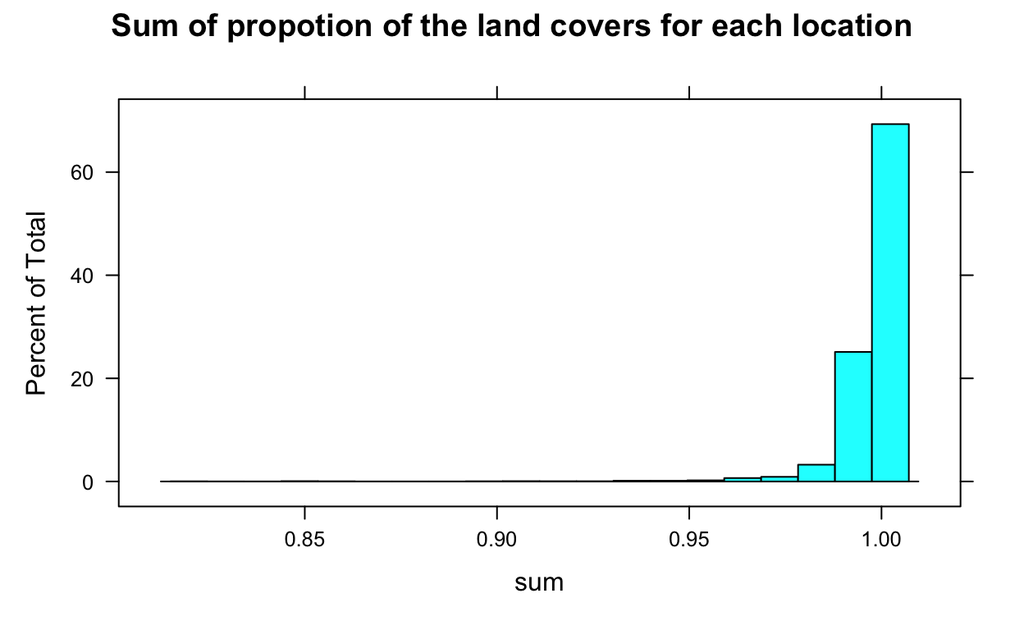

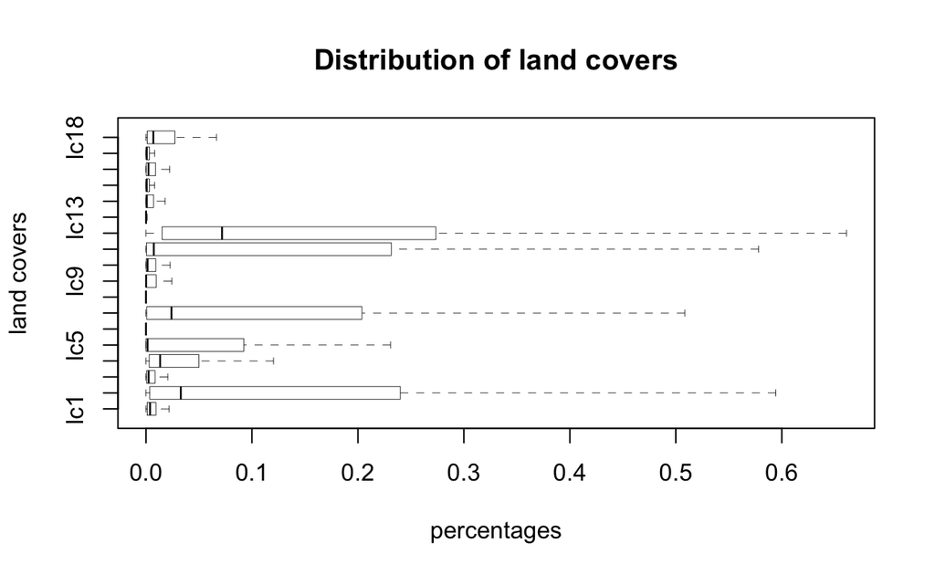

In Figure(), we can see the distribution of land covers using Boxplot. We can see that most of the land cover represent less than 10% of the the area considered. Meaning that the areas considered are very diverse.

We decided transform the temperature from Kelvin to Celsius. We also decide to aggregate the U-component of wind (the wind speed in Eastern direction) and V-component of wind (the wind speed in Northern direction) and use the euclidian norm of the vector:
$$Wind_{speed_{new}}=\sqrt{Wind_{speed_{East}}^2 + Wind_{speed_{West}}^2 }$$

## Wildfires and the land cover:

### Corrolation between Land covers and Wildfires:

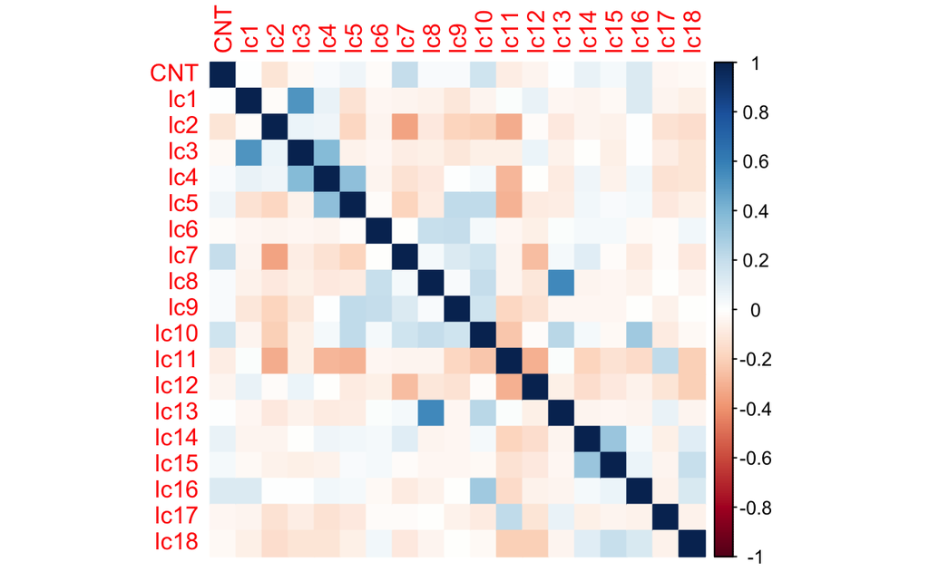

We want to determine if there is a significant correlation between the different land covers and the appearance of fires. In order to do so, we use a database filtered of missing data. As can be seen in Figure (?), the correlation between the fire and the land cover remains very low. To confirm this statement, we plot in Figure(?) the variables that have been defined as highly correlated in red and the rest in light blue. We can then see that there is no strong correlation between the features nor between the features and the apparition of the fires. We define a correlation as strong when its absolute value exceeds 0.8.

We can nonetheless note that, besides being small, the correlation between the apparation of fires and cropland rainfed herbaceous cover, mosaic cropland, shrubland, grassland, bare areas and water is negative, while the correlation with mosaic natural vegetation, tree broadleaved evergreen closed to open, tree broadleaved deciduous closed to open, tree needleleave evergreen closed to open, tree needleleaved deciduous closed to open, tree mixed, mosaic tree and shrub, sparse vegetation, tree cover flooded fresh or brakish water, shrub or herbaceous cover flooded and urban areas is positive.

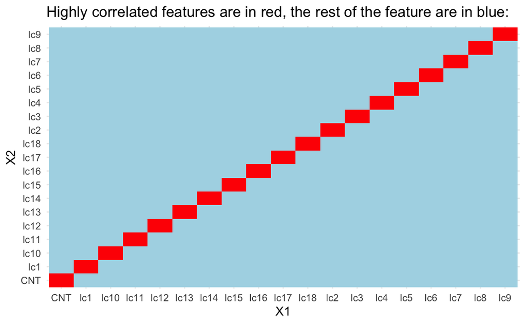

### Land cover over time and location:

In this section, we will study the distribution of land covers over time. To do so, we have selected the geographical coordinates of Malibu, California. This area has been heavily impacted by wildfires in recent years. ‘In November 2018, the wealthy coastal enclave of Malibu was engulfed by the Woolsey Fire, which spread to over 96,000 acres of land outside of LA and is now 35% contained. At least two people were pronounced dead in Malibu on Friday. Their burned bodies were found in a car near Mulholland Highway’ Aria Bendix (2018). In Figure (), we can see the exact location of the studied point on the map of the United States.

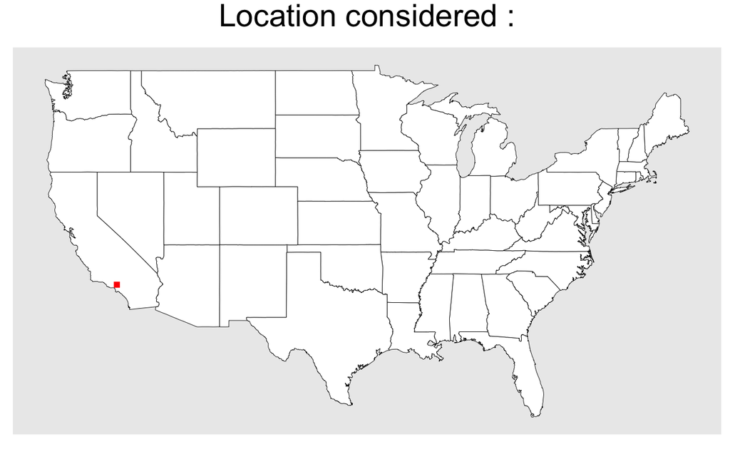

In Figure (), we can see the distribution of the land covers with time. We can see that the proportions are relatively stable and consistent with time. The predominant cover is the urban area with 31% of the surface in 1993 this proportion only increases with time.

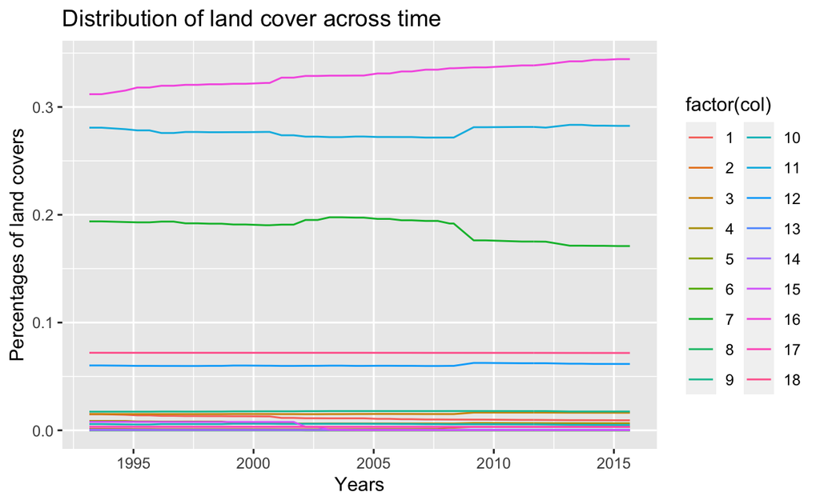

Although in this particular example of Malibu, the proportion of different land covers seems consistent, this is not always the case. Taking the coordinates in Figure () in Wisconsin, we can see that the proportions change drastically depending on the year. The percentage of land representing tree broadleaved evergreen closed to open increases with time until it becomes the predominant one, while shrub or herbaceous cover flooded decreases drastically with time as seen in Figure(). We will not analyze the reasons and parameters that may have motivated this change, but we will try to quantify this change in the next section.

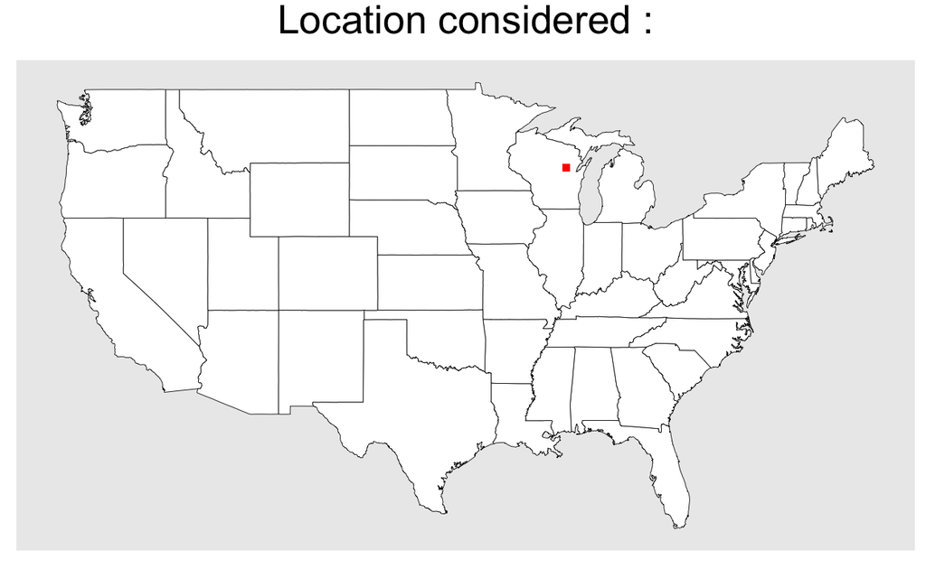

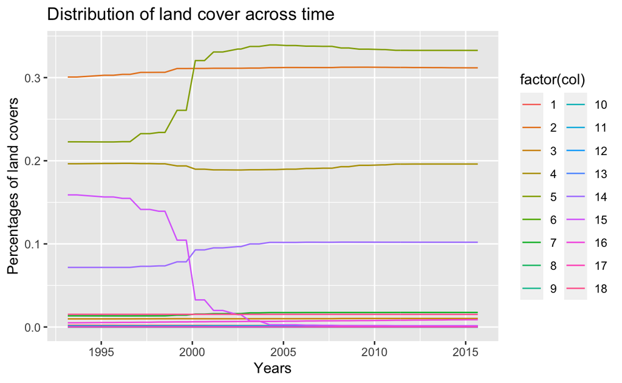

To access the intarctive part, click [this link](https://zinebag.shinyapps.io/LandCovers/). In this app you will able to select the longitude and lattitude wanted and see the distribution of the land covers.

### Predominant Land covers Analysis and Shifts:

We will first proceed by representing the territory according to the predominant type of coverage. Figure () shows this arrangement in 2000. We observe that water dominates the maritime borders, tree broadleaved are predominant in the east of the country while the west is dominated by tree needleleave. We can easily identify the cities of New York, Los angeles and other large cities by their predominance of urban space.

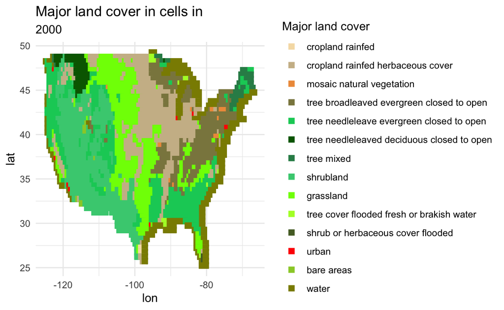

To access the intarctive part, click [this link](https://zinebag.shinyapps.io/AppShift/). In this app you will able to select the year and the predominant land cover will display directly on the us map.

We can also compare the occurence of fires in a location with its predominant land cover.

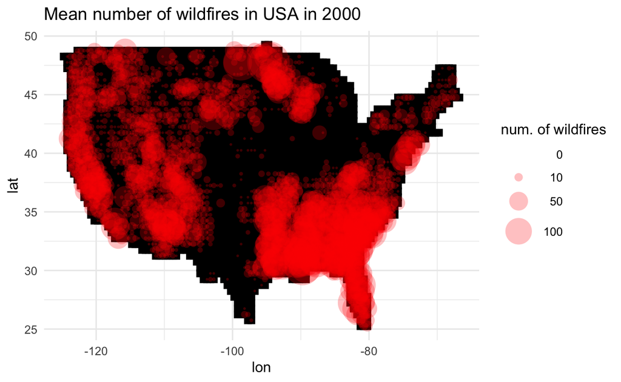

Also, we can observe that the closeness of urban land cover is correlated with occurrence of wildfires (For instance near New York city and Los Angeles), meaning that the human activity can be the trigger of wildfires. Other commonly known trigger of wildfires is the presence of dry thunderstorms with high activity of cloud-to-ground flashes. This mentioned trigger is usually the cause of the higher frequency of big wildfires in the Pacific Coast.

The combination of grassland with needle-leaved trees might be dangerous as can be visible on the Fig() and Fig().

The presence of needle-leaved trees for wildfires is crucial, since the trees are closer to each-other and the dead branches on the floor with sap provide enough fuel to higher spread of wildfire. Moreover, the land cover of deciduous trees can be especially dangerous in the early spring. The article by Barros et al. (Barros, Ana M. G. and Pereira, José M. C. (2014)) studying the fire selectivity in Portugal suggests that the selectivity for wildfire counts is higher for shrublands, grasslands and conifers, but lower for agricultural areas such as cropland. This suggestion seems to be confirmed in the US by the early observations of the Figures () and ().

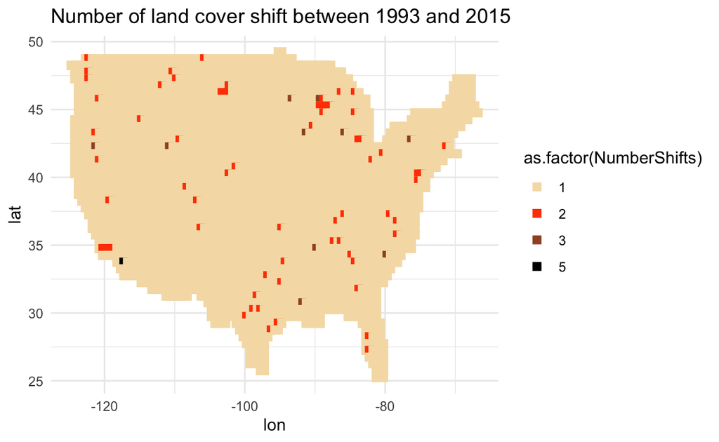

To analyze the variation, we create a vector whose values start at zero for any given location and increases by one as soon as the predominant coverage area changes from one month to the next. What is first interesting to note is that all locations change their predominant landcover at least once. Indeed in Figure (), we see that the shift values start at 1. We also see that the shifts do not exceed 5, knowing that this measurement is taken over 22 years, this is still relatively low. Note that we will not further research on the reason behind these changes during this project due to lack of time.

### Land covers and meteorogical correlation

We want to understand the correlation between land covers and meteorological variables. To do so, we are going to clean our data first, rename the variables by their description so that we can easily analyze our results and then compute the correlation between the variables. The problem is that when trying to output the matrix, we get a warning saying that the matrix is too big. To get an glimpse of what variable can be highly related, we are going to output the correlation between a pair of land cover and meteorological variable when it is bigger than a threshold manually set.

```
[1] "cor("               "11"                 ","
[4] "7"                  ")="                 "-0.722896324256492"
```

Here, we choose a threshold of 0.6 and none of the correlations has been displayed except one. This means that those who haven’t been printed are less that 0.6. We get that the correlation between the shrublands and the surface net thermal radiation is of -0.72. This seems normal: the more radiation is issued by the surface, the less shrub we get. But the results are not as good as expected. In fact, when printing all the correlations (threshold = 0) we remark that the values are very small. This can come from the fact that there are no correlations between the variables or that the dependence is not linear here. So we are going to compute the correlation with spearman method to see if the relation between the variables is monotonic.

```
[1] "cor("               "11"                 ","
[4] "7"                  ")="                 "-0.626147167673006"
```

```
[1] "cor("              "16"                ","
[4] "8"                 ")="                "0.691392764491666"
```

```
[1] "cor("            "18"              ","
[4] "8"               ")="              "0.6009781819297"
```

Now by changing the method, we observe that we get that the land cover variable 11 (shrubland) and the surface net thermal radiation are correlated, same result as earlier. And, we also get that the water, urban and surface pressure are correlated. The pressure in the water is higher that the atmospheric pressure and increases with the depth. The pollution of the air explains the positive correlation between urban lands and surface pressure. To visualize our results and try to show more, we are going to regroup our data so that we can compute a correlation matrix. We take variables of land covers that are similar and have a common characteristic and sum them together.

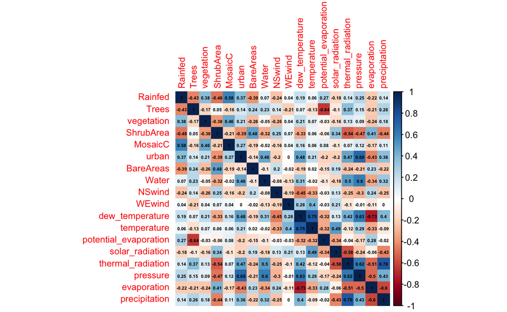

This technique has been useful to represent our previous result. Also we get that Evaporation is negatively correlated with the trees, meaning the more trees there are, less evaporation there is. For the next project, one can think of trying to find correlation between other land cover and meteorological data by plotting the scatter plot to find a curve that approximate the data.

### Spreading fire based on the type of land cover

First, to analyze the spread of a fire, we are going to look for the distribution of the number of fires in a grid during a month.

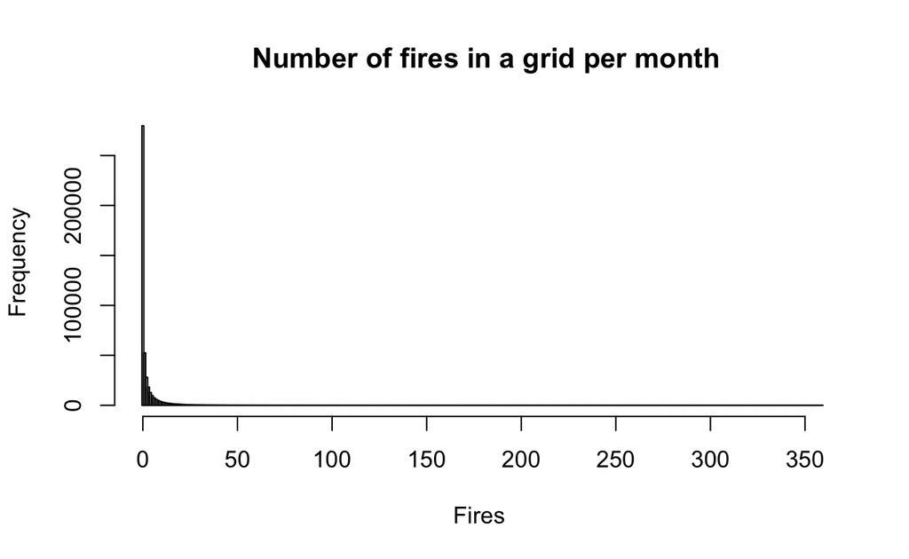

We remark that most of the values are close to 0 and because of the outliers we can’t see the distribution very good. So we are going to filter the outliers to have a better view of the distrubution

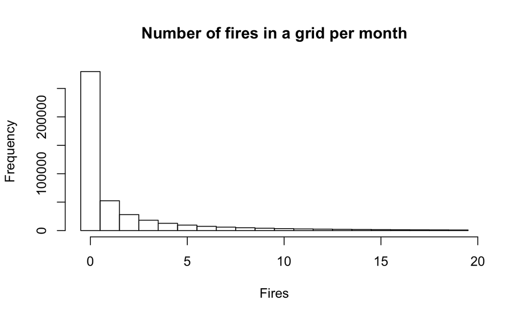

Now, since we want to predict the spread of a fire given the land covers data, let’s plot the distribution of the number of fire according to each land cover variable.

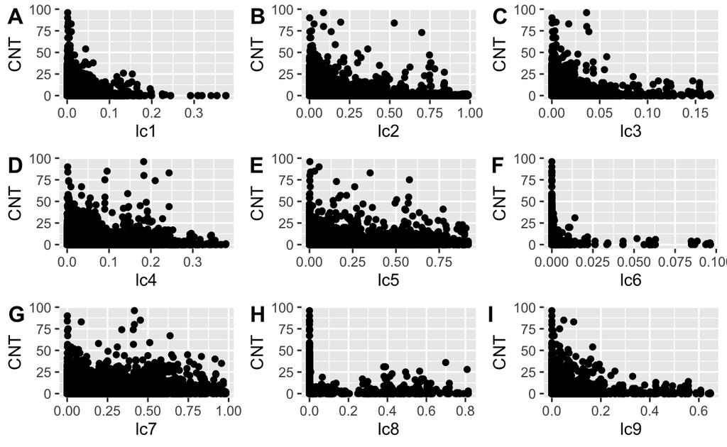

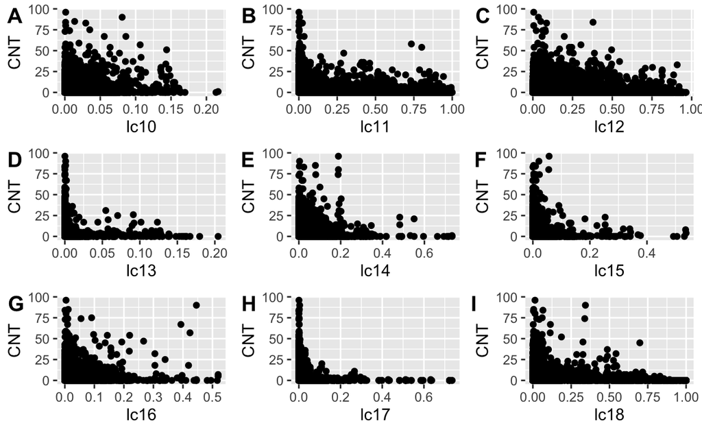

In this section, we try to model the fact that there was a fire in a grid for a given month given the land cover specification of the grid. The problem is that we have the number of fire in the grid. One can think of using the zero inflated Poisson regression. In fact, the zero inflated Poisson is used to count data with excess zeros and overdispersion, which describe well our data. It combines the Poisson distribution and the logit distribution.

```
Call:
zeroinfl(formula = CNT ~ lc1 + lc2 + lc3 + lc4 + lc5 + lc6 +
    lc7 + lc8 + lc9 + lc10 + lc11 + lc12 + lc13 + lc14 + lc15 +
    lc16 + lc17 + lc18, data = df)

Pearson residuals:
     Min       1Q   Median       3Q      Max
 -2.6002  -0.6556  -0.4760  -0.1269 164.8916

Count model coefficients (poisson with log link):
            Estimate Std. Error z value Pr(>|z|)
(Intercept)  -0.4275     0.1150  -3.718 0.000201 ***
lc1           3.8936     0.1317  29.561  < 2e-16 ***
lc2           1.7546     0.1152  15.234  < 2e-16 ***
lc3           0.1621     0.1427   1.136 0.255880
lc4           2.5901     0.1170  22.144  < 2e-16 ***
lc5           2.3983     0.1148  20.897  < 2e-16 ***
lc6          -7.7769     0.4706 -16.526  < 2e-16 ***
lc7           2.6995     0.1149  23.490  < 2e-16 ***
lc8           2.3755     0.1158  20.514  < 2e-16 ***
lc9           1.0370     0.1172   8.845  < 2e-16 ***
lc10          4.5284     0.1232  36.762  < 2e-16 ***
lc11          1.5169     0.1153  13.158  < 2e-16 ***
lc12          1.9933     0.1155  17.256  < 2e-16 ***
lc13         -1.5373     0.1658  -9.271  < 2e-16 ***
lc14          2.7590     0.1212  22.764  < 2e-16 ***
lc15          2.5966     0.1282  20.260  < 2e-16 ***
lc16          5.8753     0.1176  49.973  < 2e-16 ***
lc17         -0.3846     0.1310  -2.937 0.003314 **
lc18          1.4079     0.1162  12.121  < 2e-16 ***

Zero-inflation model coefficients (binomial with logit link):
            Estimate Std. Error z value Pr(>|z|)
(Intercept)  -9.8587     0.4163  -23.68  < 2e-16 ***
lc1           9.8726     0.4567   21.62  < 2e-16 ***
lc2          11.9956     0.4168   28.78  < 2e-16 ***
lc3          12.7570     0.4947   25.79  < 2e-16 ***
lc4           9.9462     0.4243   23.44  < 2e-16 ***
lc5          10.0305     0.4162   24.10  < 2e-16 ***
lc6          18.0285     1.0028   17.98  < 2e-16 ***
lc7           8.0604     0.4164   19.36  < 2e-16 ***
lc8           9.4954     0.4201   22.60  < 2e-16 ***
lc9          11.0770     0.4201   26.37  < 2e-16 ***
lc10          1.2508     0.4685    2.67  0.00759 **
lc11         10.7596     0.4172   25.79  < 2e-16 ***
lc12         10.8828     0.4172   26.08  < 2e-16 ***
lc13         16.6698     0.5593   29.81  < 2e-16 ***
lc14          8.6888     0.4388   19.80  < 2e-16 ***
lc15          9.2563     0.4608   20.09  < 2e-16 ***
lc16          7.3972     0.4386   16.87  < 2e-16 ***
lc17         12.1465     0.4312   28.17  < 2e-16 ***
lc18         11.4647     0.4180   27.43  < 2e-16 ***
---
Signif. codes:  0 '***' 0.001 '**' 0.01 '*' 0.05 '.' 0.1 ' ' 1

Number of iterations in BFGS optimization: 43
Log-likelihood: -1.138e+06 on 38 Df
```

Below, you can find a block of output containing Poisson regression coefficients for each of the variables along with the standard errors, z-score and p-values for the coefficients. A second block follows with the inflation model which includes logit coefficients for predicting excess zeros. All of the predictions in both the count and inflation portion are statistically significant ( all p-values are very small) except for the land cover 3 in the count model. But otherwise this means that the null hypothesis that the coefficient is equal to 0 is rejected for all the coefficients. This means that this model fits the data significantly better than the null model.

## Wildfires and meteorogical factors

In this section, we try to find some meteorological factors that could potentially trigger a wildfire. To do so, we will plot a Pearson correlation heatmap. The first step is to get a subset from our initial dataset that is more representative of wildfire conditions. As a fire is quite a rare event, we will not be able to find any links if we were considering the entire population (the correlations would be around 0).

To get our subset, we will only consider areas per month which have at least a certain number of wildfires and which have been burnt above a certain threshold. For our example, we take rows with more than 60 wildfires ($CNT \geq 60$) and 5000 acres of aggregated burnt area ($BA \geq 5000$, approximately 20km<sup>2</sup>) in the current month.

We check whether the period in years of the subset matches that of the initial dataset, i.e. 1993 to 2015. We see that it does.

```r
range(selection$year)
```

```
[1] 1993 2015
```

As a result, a correlation heatmap will allow us to distinguish certain factors that could favor a wildfire.

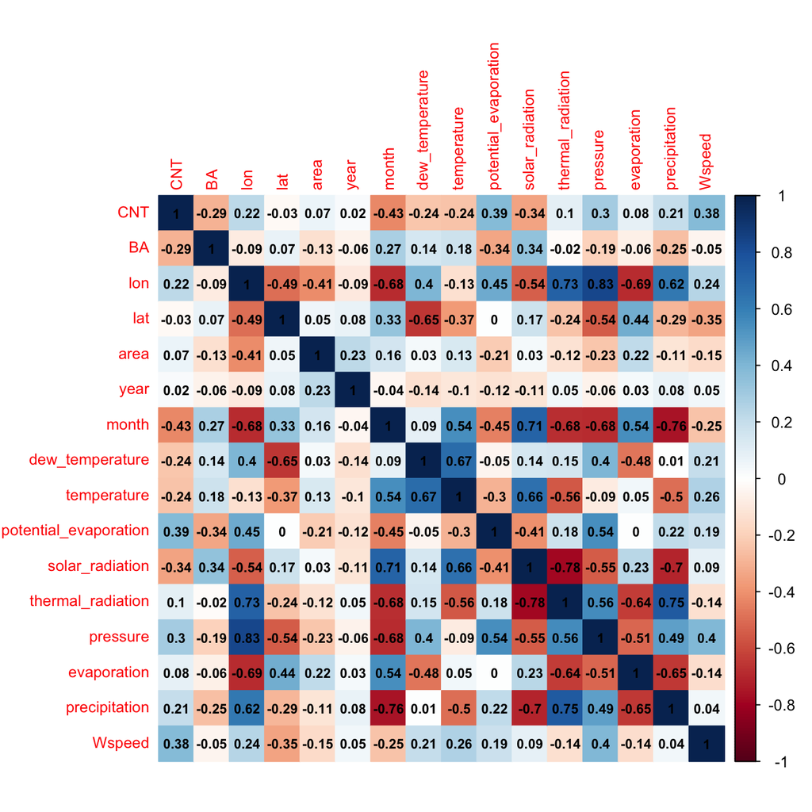

Since we are looking for meteorological risk factors, we may only consider the first two rows or columns of the heatmap.

First, we see that there are no pairs of fully correlated variables. Indeed, the highest value (absolute) is 0.43. The number of wildfires and months are negatively correlated. This can be explained by the fact that months range from March to September and that there are more occurrences of fire in March and April than in August and September. The fact that the numbers are small shows that the causes of a wildfire are meteorologically multifactorial.

An interesting observation is that $CNT$ and $BA$ are negatively correlated, meaning that the more area burnt, the fewer wildfires there are. Most of the time, the signs of correlations in the first two rows are not the same for these two variables. For example, by looking at temperatures and solar radiation, the higher they are, the more area burnt, but the less wildfires. This can be explained by the fact that our subset contains substantial wildfires, so there aren’t many, but they are destructive.

Another variable that we can comment on is precipitation. For an area to be burnt, there must be no rain or high humidity conditions, hence the negative correlations between $BA$ and precipitation. The positive correlation with $CNT$ could be explained by unstable weather conditions. As with wind speed, the higher it is, the more unstable the air masses and the greater the risk of a natural disaster.

But we should be careful with these correlations as we used a subset and as their values are not that high in absolute value.

Next, a map of the US represents the areas considered in the subset, regardless of months and years.

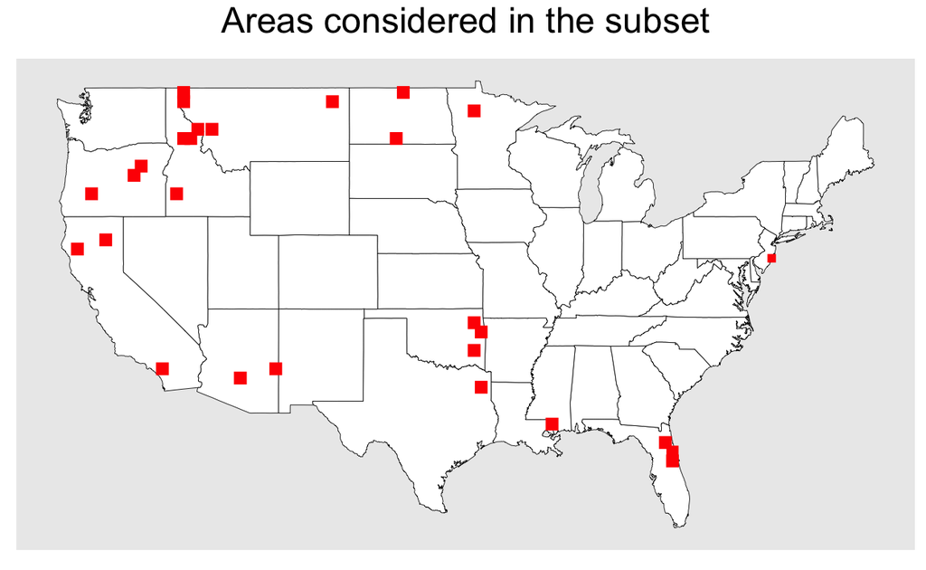

It can be seen that the areas represented are not that many in number and are located where the forest cover is the most important. For example, there are almost no red squares in the central region of the United States, as this area is mostly non-forest land.

For other thresholds, an interactive app is available [here](https://fahimbeck.shinyapps.io/wildfires_mfactors/). Instructions and explanations are displayed on the app. Basically, you have the same results as above, but thresholds for $CNT$ and $BA$ are entered by the user.

## Subgroup analysis

The histogram in Fig. (), had a long tail, which indicates that many of the fires arise in a small subset of geographical gridpoints. In other words, there is considerable heterogeneity between the geographical gridpoints. Furthermore, in the interactive app which explored meteorological correlations, it was found that meteorological variables were more strongly correlated with the number of wildfires in subgroups of geographical gridpoints with a large number of fires. This motivated us to conduct an explicit subgroup analysis by employing quantile regression. We employed the linear quantile regression model
$$Q_\cdot(\tau\mid X) = a_0(\tau) + b_0(\tau)X$$
where $X$ is a covariate (risk factor), $\cdot$ is the number of wildfires ($N$) or the burnt area ($A$) in a given geographical gridpoint during a given month and $Q_\cdot(\tau\mid X)$ is the quantile corresponding to percentile $\tau$. This model allows us to explore dynamic covariate effects of $X$ across strata of $\tau$. In Fig. (), we have fit the quantile regression model with $X=$ temperature for a random sample of 10 000 geographical gridpoints from the year 2015.

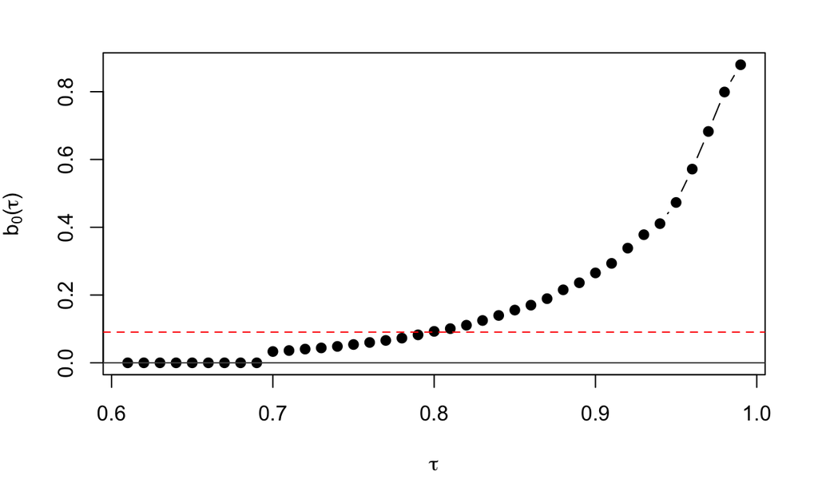

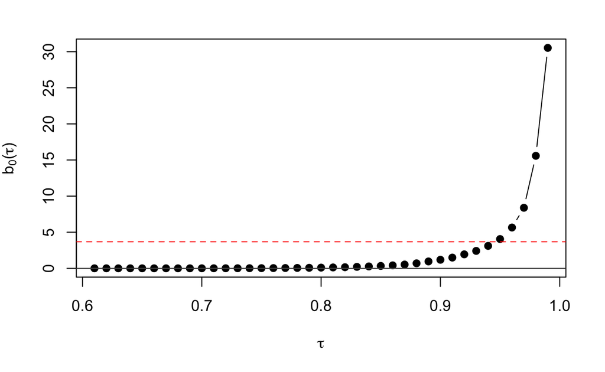

Whereas the association between temperature and wildfire outcomes (i.e. number of wildfires and burnt area) is not very strong in the marginal analyses conducted earlier (unconditional on $\tau$), we observe a very clear association within strata given by percentiles of number of wildfires or burnt area. This indicates that temperature has a heterogeneous effect on wildfires: it is evident that temperature exacerbates the probability of wildfires in areas that are prone to these. As a control, we have repeated the analysis with the exposure $X$ being the proportion $W$ of land cover constituted by water below:

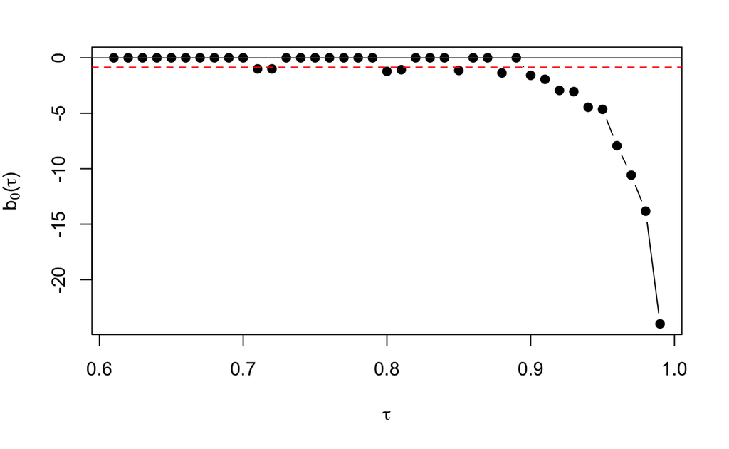

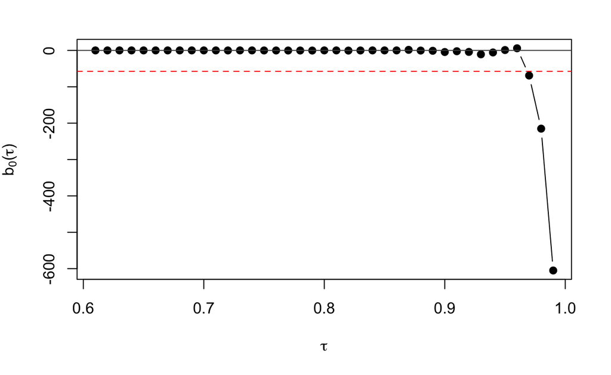

The negative control shows what we expect: areas which are susceptible to wildfires experience substantially less of these the larger the proportion of land cover that is constituted by water. These illustrations highlight the power of quantile regression in elucidating heterogeneous covariate effects across units.

The strong association between temperature and wildfires for large quantiles for wildfire outcomes prompots us to consider how the yearly mean temperature has evolved with time. In the plot below, we observe a weakly rising trend. We therefore remark that we may experience an exacerbation of wildfires in the future, if temperatures continue to rise.

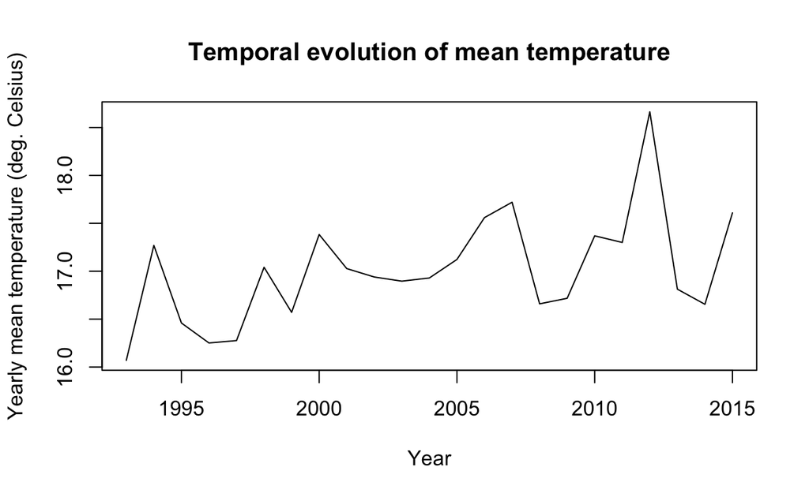

## Conclusion

Most of our analysis has targeted marginal associations between risk factors and the number of wildfires or aggregate burnt area (i.e. unconditional on subsets of geographical gridpoints). These correlations were often weak, but grew stronger in subsets of the population with a greater number of wildfires. This motivated us to characterize the heterogeneity in risk of wildfires by conducting subgroup analyses. To do so, we performed quantile regression, which revealed that temperature substantially exacerbated the risk of wildfires in areas which are prone to wildfires. This is in spite of the fact that temperature was only weakly associated with wildfires marginally.

Furthermore, we have seen a weakly rising trend in the temperature over the past years. Coupled with our observation fact that the proportion of urban land cover has been rising steadily with time, and that human activity is an important cause of wildfires, we note that we may see an increased occurrence of wildfires in the years to come.

## Future improvements

An extension to our analysis would be to use our data to do some predictions. So it would also be advantageous to find a more recent dataset, since ours is limited to 2015. As a consequence, we could perceive a more important effect of global warming, and previous correlations might appear more distinctly.

Another improvement would be to look at other regions that are subject to wildfires, such as Australia or African countries. This would increase our dataset and help us capture the main factors and causes by comparing the areas (more heterogeneity in our data).

Alejandra Borunda. 2021. *The Science Connecting Wildfires to Climate Change*. *National Geographic*. https://www.nationalgeographic.com/science/article/climate-change-increases-risk-fires-western-us.

André Gabrielli. 2019. *Wildfires*. *National Geographic*. https://www.nationalgeographic.org/encyclopedia/wildfires/.

Barros, Ana M. G. and Pereira, José M. C. 2014. *Wildfire Selectivity for Land Cover Type: Does Size Matter?* *PloS One*. Vol. 9. Public Library of Science.

Holly Yan, Cheri Mossburg, Artemis Moshtaghian and Paul Vercammen. 2020. *California Sets New Record for Land Torched by Wildfires as 224 People Escape by Air from a ’Hellish’ Inferno*. *CNN*. https://edition.cnn.com/2020/09/05/us/california-mammoth-pool-reservoir-camp-fire/index.html.

Mert Ozkan and Ezgi Erkoyun. 2021. *Turkish Wildfires Are Worst Ever, Erdogan Says, as Power Plant Breached*. *Reuters*. https://www.reuters.com/world/middle-east/fire-near-turkish-power-plant-under-control-local-mayor-2021-08-04/.

Michael Slezak. 2020. *3 Billion Animals Killed or Displaced in Black Summer Bushfires, Study Estimates*. *ABC News*. https://www.abc.net.au/news/2020-07-28/3-billion-animals-killed-displaced-in-fires-wwf-study/12497976.

Sarah Gibbens. 2021. *Wildfire Smoke Blowing Across the U.s. Is More Toxic Than We Thought*. *National Geographic*. https://www.nationalgeographic.com/environment/article/wildfire-smoke-blowing-across-country-more-toxic-than-we-thought.

Schaefer, Alexander J. and Magi, Brian I. 2019. *Land-Cover Dependent Relationships Between Fire and Soil Moisture*. *Fire*. Vol. 2. Multidisciplinary Digital Publishing Institute.

Steven Reinberg. 2021. *Wildfires Cause More Than 33,000 Deaths Globally Each Year*. *U.S. News*. https://www.usnews.com/news/health-news/articles/2021-09-09/wildfires-cause-more-than-33-000-deaths-globally-each-year.

Topher Gauk-Roger, Stella Chan, Jason Hanna and Steve Almasy. 2020. *California Wildfires: Fire Chief Says Dozens of Major Blazes Have State in ’Dire Situation’*. *CNN*. https://www.cnn.com/2020/09/08/us/california-fires-tuesday/index.html.

*Wildfire Causes*. n.d. *British Columbia*. https://www2.gov.bc.ca/gov/content/safety/wildfire-status/about-bcws/wildfire-response/fire-characteristics/causes.